# Time-series & cryptocurrencies

**WARNING**: this notebook relies on several **R packages**. Whenever one is called (for instance via a call such as “*library(torch)*”), this implies that the package has been installed, e.g., via “*install.packages(”torch”)*”. Hence, make sure the following packages are installed!

```r
# install.packages("tidyverse")
# install.packages(c("forecast", "quantmod", "crypto2", "RcppRoll", "rugarch", "fGarch", "fable", "tsibble", "feasts"))
```

```r
library(tidyverse)
```

# Crash course on time-series

## Definitions & notations

Time-series are random variables indexed by time. Usually, they are written $x_t$, or $X_t$ or $y_t$ or similar notations of this kind. The index $t$ refers to *time*. The essential question in time-series is to determine the law of motion of the process, as well as its characteristics.

Most often, the process integrates some form of randomness, which is usually written $e_t$, $\epsilon_t$ or $\varepsilon_t$. There are two common simplifying assumptions that are made with respect to these quantities, which are sometimes referred to as *innovations* or *residuals*:

1. they can be normally distribution (with Gaussian law);
2. they are independent from each-other.

**NOTE**: in almost all models, innovations have zero means, $\mathbb{E}[e_t]=0$, hence in the case of Gaussian innovations, only the variance $\sigma^2$ is specified. We will work under these (standard) assumptions below.

## Examples

### The random walk

The simplest case is the **white noise**:
$$x_t= e_t,$$

but this is not very interesting. A second important case is linked to the notion of *random walk*:
$$x_t=x_{t-1}+e_t,$$
and, iterating, we see that we have $x_t=\sum_{s=0}^t e_s$ - where we assume a starting point at $t=0$. Notably, we have
$$\mathbb{E}[x_t]=\mathbb{E}\left[\sum_{s=0}^t e_s\right]=\sum_{s=0}^t\mathbb{E}\left[ e_s\right]=0.$$

Moreover, if the innovations are independent,

$$\mathbb{V}[x_t]=\mathbb{V}\left[\sum_{s=0}^t e_s\right]=\sum_{s=0}^t\mathbb{V}\left[ e_s\right]=t\sigma^2.$$

Hence, the variance increases with time - linearly. If perturbations are *not* independent, then it’s a bit more complicated and the variance will depend on all *auto-covariances*.

The covariance between two points in time is given by:

$$\mathbb{C}ov[x_t,x_{t+h}]=t\sigma^2, \quad h \ge 0.$$
This is because all innovation terms are independent, hence the only ones that are non-null are the $t$ terms of the form $\mathbb{C}ov[x_s,x_s]=\sigma$.

Hence, we see that both the variance and auto-covariance depend on $t$, say, the present time. This makes analysis complicated, because, depending on the moment we consider, the distribution of $x_t$ will change.

Let’s simulate one trajectory.

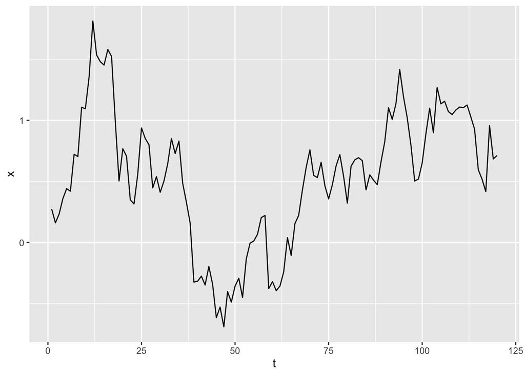

```r
set.seed(42) # This freezes the random number generator
N <- 120
sigma <- 0.2
x <- cumsum(rnorm(N, mean = 0, sd = sigma))
tibble(t = 1:N, x = x) |>
  ggplot(aes(x = t, y = x)) + geom_line()
```

### The auto-regressive model

Let us introduce a small modification to the above process and consider:
$$x_t=a+\rho x_{t-1}+e_t, \quad a \in \mathbb{R}, \quad |\rho|< 1.$$
This process is called the Auto-Regressive model of order one and is written AR(1). Iterating, we have:
$$x_t = a + \rho (a + \rho x_{t-2}+e_{t-1})+e_{t}$$
and, until infinity…
$$x_t=a \sum_{k=0}^\infty\rho^k+ \sum_{k=0}^\infty \rho^ke_{t-k}=\frac{a}{1-\rho}+ \sum_{k=0}^\infty \rho^ke_{t-k},$$
which explains why we need $|\rho|<1$.

Again, we have

$$\mathbb{E}[x_t]=\frac{a}{1-\rho},$$
and when innovations are independent,
$$\mathbb{V}[x_t]=\mathbb{V}\left[\sum_{k=0}^\infty \rho^ke_{t-k} \right]=\sum_{k=0}^\infty \mathbb{V}\left[\rho^ke_{t-k} \right]=\frac{\sigma^2}{1-\rho^2}.$$

In this case, we see that the **mean** and **variance** do not depend on $t$!

Moreover,

$$\mathbb{C}ov[x_t,x_{t+h}]=\mathbb{C}ov\left[\sum_{k=0}^\infty \rho^ke_{t-k} ,\sum_{j=0}^\infty \rho^je_{t-j+h} \right]=\sum_{k=0}^\infty \sum_{j=0}^\infty \mathbb{C}ov\left[ \rho^ke_{t-k}, \rho^je_{t-j+h} \right]$$
Again, we need to focus on the cases when the time indices are equal, so
$$\mathbb{C}ov[x_t,x_{t+h}]=\sum_{k=0}^\infty \sum_{j=h}^\infty \mathbb{C}ov\left[ \rho^ke_{t-k}, \rho^{j-h}e_{t-j} \right]=\sum_{k=0}^\infty \sum_{j=h}^\infty \rho^{k+j-h}\mathbb{C}ov[e_{t-k},e_{t-j} ]$$

Thus, for $j=k$, we get
$$\mathbb{C}ov[x_t,x_{t+h}]=\sigma \sum_{j=h}^\infty \rho^{2j-h}=\sigma^2 \rho^h \sum_{j=0}^\infty \rho^{2j}=\sigma^2\frac{\rho^h}{1-\rho^2}.$$
Again, this does not depend on the time index $t$. If innovations are Gaussian, as Gaussian distributions are entirely defined by their first two moments, this means that the full (unconditional) distribution of the process is **invariant**. This very convenient property is called **stationarity**, and comes in various flavors (have a look on the net!). It is very suitable for analysis because now we know that the object that we study (the underlying distribution) is stable in time.

The above quantity, which measures the link between different realizations of the same variable (at different points in time) is very important. Often, the covariance is scaled by the variance to yield the **auto-correlation** of the process. Relatedly, there is the **auto-correlogram**, which is defined, for stationary series, as

$$\gamma(h)=\mathbb{C}orr[x_t,x_{t+h}].$$
For the AR(1), $\gamma(h)=\rho^h$.

More generally, autoregressive models of higher orders (AR(p)) have memory that goes back further in time:
$$x_t=a+\sum_{k=1}^p\rho_k x_{t-k}+e_t, \quad a \in \mathbb{R},$$

Even more generally, there are ARMA(p,q) processes, defined as
$$x_t=a+\sum_{k=1}^p\rho_k x_{t-k} +\sum_{j=1}^q\delta_je_{t-j}+e_t, \quad a \in \mathbb{R},$$

but more in these is left to your curiosity.

Let’s simulate two such processes. We refer to the [ARIMA](https://stat.ethz.ch/R-manual/R-devel/library/stats/html/arima.html) page for details on the implementation. The order is $(p,d,q)$, like in the ARMA(p,q) process (the $d$ is for integration, a notion out of the scope of this course).

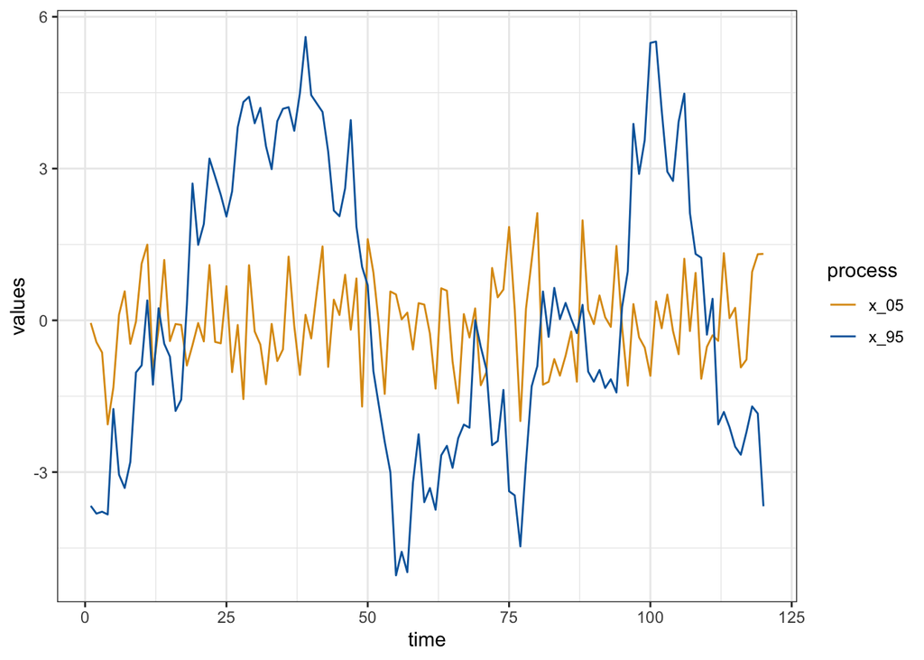

```r
x_05 <- arima.sim(list(order = c(1,0,0), ar=.05), n = N)
x_95 <- arima.sim(list(order = c(1,0,0), ar=.95), n = N)
tibble(time = 1:N, x_05 = x_05, x_95 = x_95) |>
  pivot_longer(-time, names_to = "process", values_to = "values") |>
  ggplot(aes(x = time, y = values, color = process)) + geom_line() +
  theme_bw() +
  scale_color_manual(values = c("#DD9911", "#0066AA"))
```

One of the processes seems to be just white noise, the other evolves more slowly and oscillates much less.

Let’s have a look at the auto-correlogram of the series.

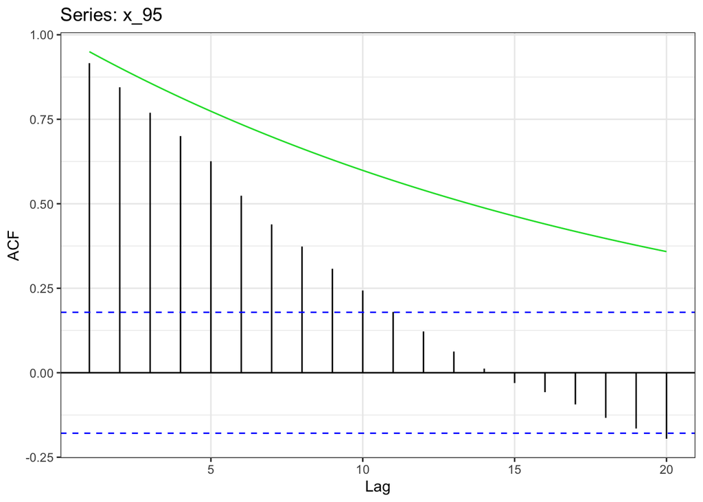

```r
library(forecast) # For the ggAcf() function
ggAcf(x_95) + theme_bw() +
  geom_function(fun = function(x) exp(x*log(0.95)), color = "#11DD33")
```

The values we extract from the sample are not exactly those predicted from the model. This comes from the fact that the sample, which is too small. As it increases, we would obtain a perfect fit (you can try!).

### ARCH models

In practice simple autoregressive models can be too limited because some variables are not exactly stationary. To illustrate this statement, let’s have a look at a volatility index, the [**VIX**](https://www.cboe.com/tradable_products/vix/). **NOTE**: usually, the volatility is the standard deviation of past returns. The VIX is slightly different, as it is based on forward-looking option prices. Still, it is linked (empirically) to the traditional volatility.

```r
library(quantmod)
min_date <- "2000-01-01"                 # Starting date
max_date <- "2023-01-27"                 # Ending date
getSymbols("^VIX", src = 'yahoo',        # The data comes from Yahoo Finance
           from = min_date,              # Start date
           to = max_date,                # End date
           auto.assign = TRUE,
           warnings = FALSE)
```

```
[1] "^VIX"
```

```r
VIX <- VIX |> as.data.frame() |>
  rownames_to_column("date") |>
  mutate(date = as.Date(date))
head(VIX,7)                                   # Have a look at the result!
```

| date | VIX.Open | VIX.High | VIX.Low | VIX.Close | VIX.Volume | VIX.Adjusted |
| --- | --- | --- | --- | --- | --- | --- |
| 2000-01-03 | 24.36 | 26.15 | 23.98 | 24.21 | 0 | 24.21 |
| 2000-01-04 | 24.94 | 27.18 | 24.80 | 27.01 | 0 | 27.01 |
| 2000-01-05 | 27.98 | 29.00 | 25.85 | 26.41 | 0 | 26.41 |
| 2000-01-06 | 26.68 | 26.71 | 24.70 | 25.73 | 0 | 25.73 |
| 2000-01-07 | 25.14 | 25.17 | 21.72 | 21.72 | 0 | 21.72 |
| 2000-01-10 | 21.89 | 22.49 | 21.36 | 21.71 | 0 | 21.71 |
| 2000-01-11 | 21.98 | 22.63 | 21.69 | 22.50 | 0 | 22.50 |

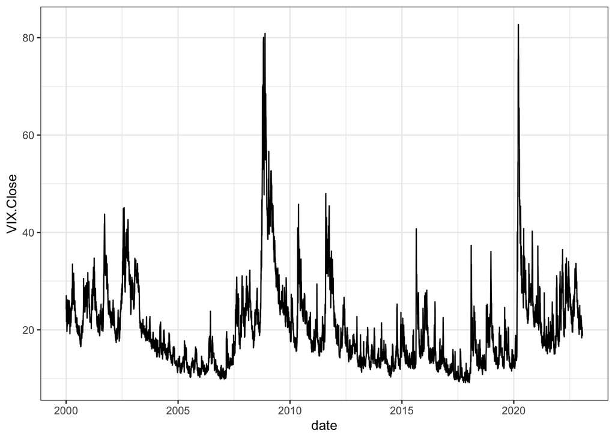

```r
VIX |> ggplot(aes(x = date, y = VIX.Close)) +
  geom_line() + theme_bw()
```

Hence, we see that the series exhibits some moments of extreme activity and its distribution is not the same through time. This is referred to as “*clusters of volatility*”.

Therefore, we also need to introduce models that allow for this type of feature. In 1982, Robert Engle proposed such a model, called [**ARCH**](https://www.jstor.org/stable/1912773), which was generalized in 1986 to [**GARCH**](https://www.sciencedirect.com/science/article/abs/pii/0304407686900631) models. As we show below, there is a direct link with auto-regressive processes!

The idea is to work with the innovations, $e_t$ and to specify them a bit differently, i.e., like this: $e_t=\sigma_t z_t$, where $\sigma_t$ is going to be a changing standard deviation and $z_t$ is a simple white noise. What matters is that the vol term is modelled as
$$\sigma^2_t = a+\sum_{j=1}^pd_j\sigma^2_{t-j} + \sum_{k=1}^qb_ke^2_{t-k},$$
hence, the value of $\sigma_t^2$ depends both on its past and on the past of squared innovations.

# Application to cryptocurrencies

For simplicity, we will work with **daily** data. Higher frequencies can be obtained outside the crypto space via the [highfrequency package](https://cran.r-project.org/web/packages/highfrequency/index.html). Or playing with dedicated APIs (e.g. with packages: [binance](https://cran.r-project.org/web/packages/binancer/index.html)/[coinmarketcap](https://cran.r-project.org/web/packages/coinmarketcapr/readme/README.html)).

## Fetching data

We will use the **crypto2** package below. If need be: install it.

```r
library(lubridate)
library(crypto2)
```

First, let’s have a look at the list of available coins… which are numerous!

```r
coins <- crypto_list()
```

You can have a look at the info for the coins via the commented code below.

```r
c_info <- crypto_info(coin_list = coins, limit = 30)
```

```
❯ Scraping crypto info
```

```
Scraping  https://web-api.coinmarketcap.com/v1/cryptocurrency/info?id=1,2,3,4,5,6,8,10,13,16,18,25,35,42,43,45,52,53,56,61,64,66,67,69,72,74,77,78,80,83  with  142  characters!
❯ Processing crypto info
```

Next, we can download historical quotes.

```r
coin_symb <- c("BTC", "ETH", "DOGE", "USDT", "BNB", "USDC", "XRP")
coin_hist <- crypto_history(coins |> filter(symbol %in% coin_symb),
                            start_date = "20170101",
                            end_date = "20230325")
```

```
❯ Scraping historical crypto data
❯ Processing historical crypto data
```

```r
coin_hist <- coin_hist |>  # Timestamps are at midnight, hence we add a day.
  mutate(date = 1 + as.Date(as.POSIXct(timestamp, origin="1970-01-01")))
```

And plot them. **NOTE**: mind the log-scale for the *y*-axis.

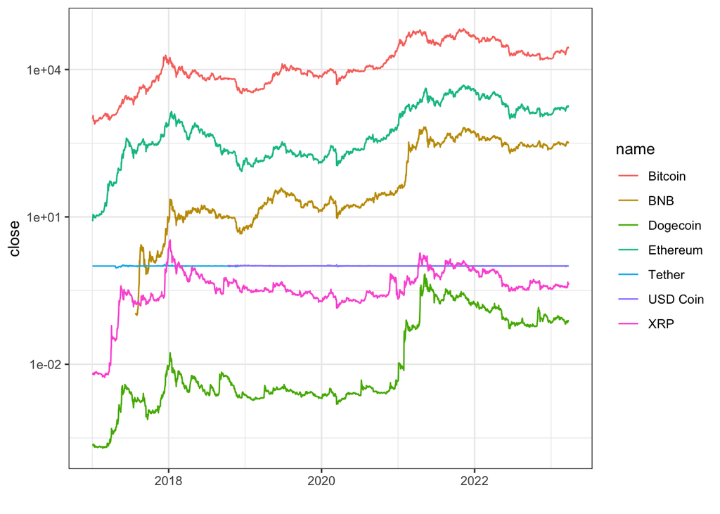

```r
coin_hist |>
  ggplot(aes(x = date, y = close, color = name)) + geom_line() +
  scale_y_log10() + theme_bw() + xlab("")
```

Now, the proble with some of these series is that they are **NOT** stationary. At the beginning of the sample, their values are much lower to those at th end of the sample. This is one of the reasons why in finance, we look at **returns**:
$$r_t=\frac{p_t-p_{t-1}}{p_{t-1}},$$
which are simply relative price changes.
Let’s compute them below. We recall that prices are gathered in the **close** column.

```r
coin_hist <- coin_hist |>
  group_by(name) |>
  mutate(return = close / lag(close) - 1 )
```

And have a look at their distributions.

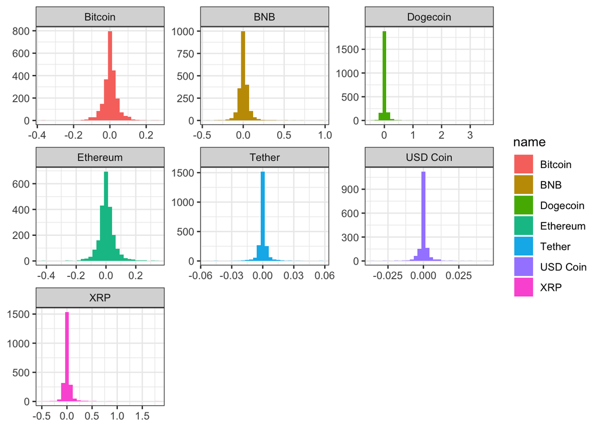

```r
coin_hist |>
  ggplot(aes(x = return, fill = name)) + geom_histogram() +
  facet_wrap(vars(name), scales = "free") + theme_bw() +
  theme(axis.title = element_blank())
```

There seem to be **outliers** (to the left or right of the most common values)!

## Estimations

Ok, so now let’s try to link what we have seen in the theoretical part with the data. This step is called **estimation**. Basically, if we think that the data follows $x_t=bx_{t-1}+e_t$, we need to find $b$!

## Returns

First, let’s have a look a autocorrelograms (of returns).

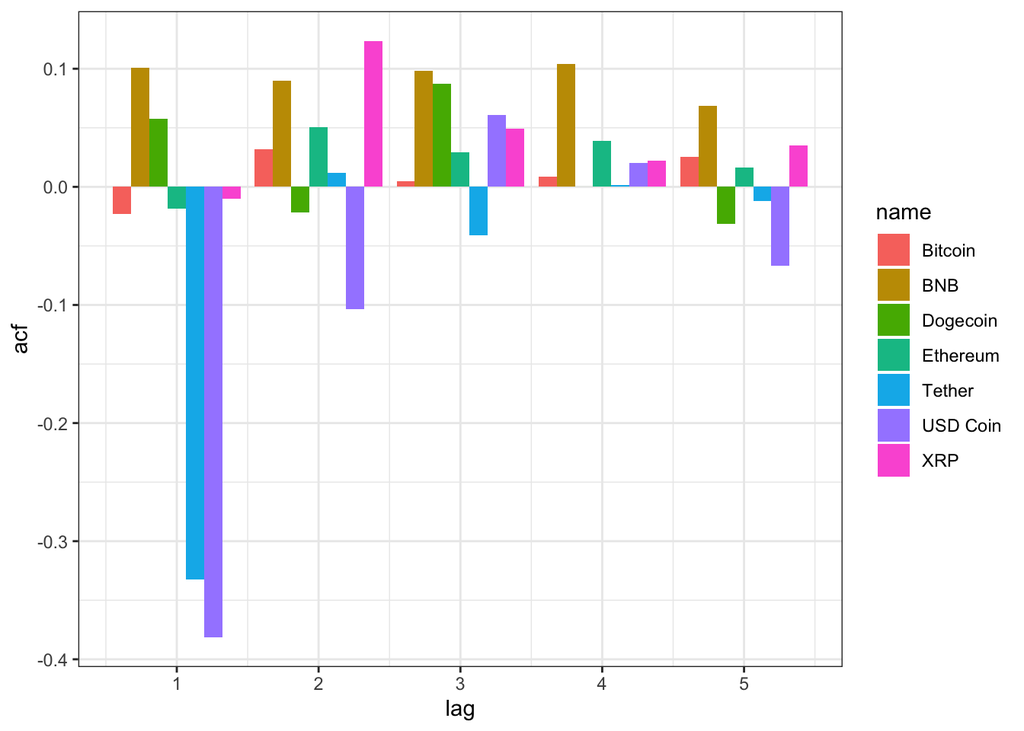

```r
crypto_acf <-
  coin_hist |>
  na.omit() %>%
    split(.$name) %>%
    map(~acf(.$return, plot = F)) %>%
    map_dfr(
      ~data.frame(lag = .$lag,
                  acf = .$acf,
                  ci = qnorm(0.975)/sqrt(.$n.used)
            ), .id = "name")
crypto_acf |>
  filter(lag > 0, lag < 6) |>
  ggplot(aes(x = lag, y = acf, fill = name)) +
  geom_col(position = "dodge") + theme_bw()
```

But recall that some of the coins are **stable**!  
Overall, however, there does not seem to be a strong memory pattern. Hence, daily returns appear to be mostly **white noise**.

## Realized volatility

Then, let’s have a look at volatility. It’s measured as

$$v_t=\sqrt{\frac{1}{T-1}\sum_{s=1}^T(r_{t-s}-\bar{r})^2},$$
where $\bar{r}$ is the mean return in the sample of $T$ observations. Below, we use an optimized (C++-based function) to compute it via rolling standard deviation over 20 days.

```r
library(RcppRoll)
coin_hist <- coin_hist |>
  group_by(name) |>
  na.omit() |>
  mutate(real_vol_20 = roll_sd(return, n = 20, fill = NA, na.rm = T))
```

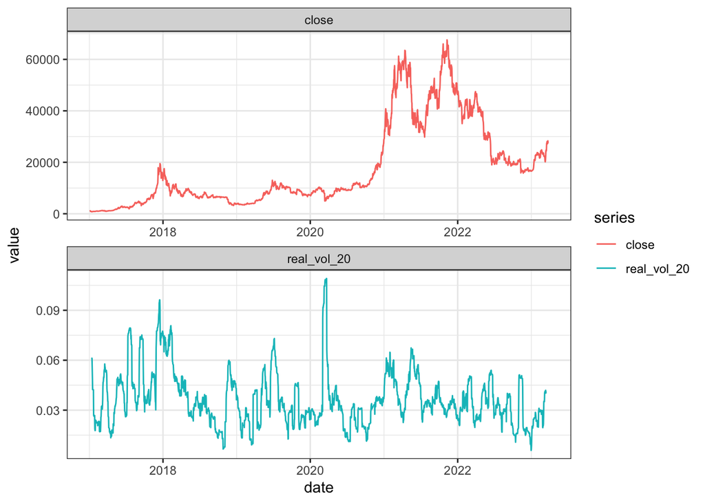

```r
coin_hist |>
  filter(name == "Bitcoin") |>
  pivot_longer(all_of(c("close", "real_vol_20")), names_to = "series", values_to = "value") |>
  ggplot(aes(x = date, y = value, color = series)) + geom_line() + theme_bw() +
  facet_wrap(vars(series), nrow = 2, scales = "free")# + scale_y_log10()
```

Now let’s have a look a the autocorrelation of the volatility: it’s highly persistent.

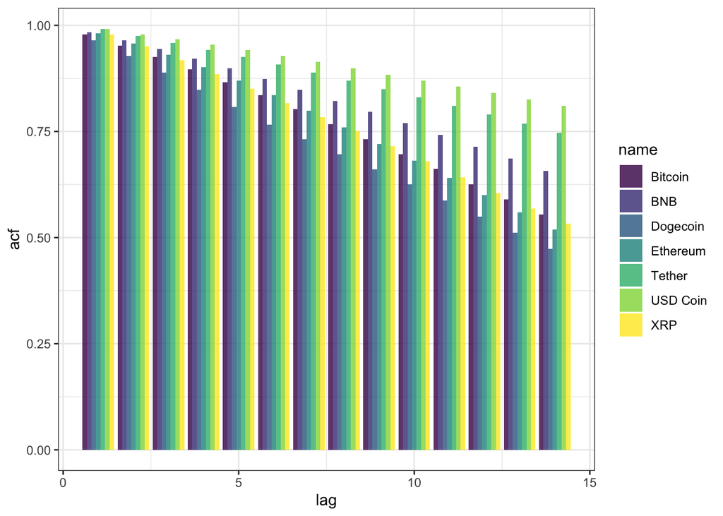

```r
crypto_acf <-
  coin_hist |>
  na.omit() %>%
    split(.$name) %>%
    map(~acf(.$real_vol_20, plot = F)) %>%
    map_dfr(
      ~data.frame(lag = .$lag,
                  acf = .$acf,
                  ci = qnorm(0.975)/sqrt(.$n.used)
            ), .id = "name")
crypto_acf |>
  filter(lag > 0, lag < 15) |>
  ggplot(aes(x = lag, y = acf, fill = name)) +
  geom_col(position = "dodge", alpha = 0.8) + theme_bw() +
  scale_fill_viridis_d()
```

## GARCH estimation

There are many packages for GARCH estimation. We propose two: [**ruGARCH**](https://cran.r-project.org/web/packages/rugarch/index.html) and [**fGARCH**](https://cran.r-project.org/web/packages/fGarch/index.html).

```r
library(rugarch)
library(fGarch)
```

In **fGARCH**, the model is:

$$s_t = \omega + \alpha e_{t-1} + \beta s_{t-1}.$$
In the output, there are some additional parameters that allow to propose a more general model:

- **shape** is the shape parameter of the conditional distribution.
- **skew** is the skewness parameter of the conditional distribution.
- **delta** a numeric value, the exponent delta of the variance recursion.

```r
garchFit(formula = ~garch(1,1),
         data = coin_hist |>
           filter(name == "Bitcoin") |>
           na.omit() |>
           pull(return))
```

[output not shown]

[output cut: 36 more lines]

[output not shown]

```
Title:
 GARCH Modelling

Call:
 garchFit(formula = ~garch(1, 1), data = pull(na.omit(filter(coin_hist,
    name == "Bitcoin")), return))

Mean and Variance Equation:
 data ~ garch(1, 1)
<environment: 0x135331400>
 [data = pull(na.omit(filter(coin_hist, name == "Bitcoin")), return)]

Conditional Distribution:
 norm

Coefficient(s):
        mu       omega      alpha1       beta1
0.00236799  0.00010123  0.10000537  0.84078296

Std. Errors:
 based on Hessian

Error Analysis:
        Estimate  Std. Error  t value Pr(>|t|)
mu     0.0023680   0.0007512    3.152  0.00162 **
omega  0.0001012   0.0000178    5.686 1.30e-08 ***
alpha1 0.1000054   0.0149331    6.697 2.13e-11 ***
beta1  0.8407830   0.0207521   40.516  < 2e-16 ***
---
Signif. codes:  0 '***' 0.001 '**' 0.01 '*' 0.05 '.' 0.1 ' ' 1

Log Likelihood:
 4178.012    normalized:  1.852777

Description:
 Tue Apr 11 21:04:31 2023 by user:
```

Now, with **rugarch**…

```r
spec <- ugarchspec()
ugarchfit(data = coin_hist |>
           filter(name == "Bitcoin") |>
           na.omit() |>
           pull(return),
           spec = spec)
```

```
*---------------------------------*
*          GARCH Model Fit        *
*---------------------------------*

Conditional Variance Dynamics
-----------------------------------
GARCH Model : sGARCH(1,1)
Mean Model  : ARFIMA(1,0,1)
Distribution    : norm

Optimal Parameters
------------------------------------
        Estimate  Std. Error  t value Pr(>|t|)
mu      0.002355    0.000744  3.16358 0.001558
ar1    -0.507177    0.565593 -0.89672 0.369871
ma1     0.492086    0.571224  0.86146 0.388985
omega   0.000101    0.000018  5.67344 0.000000
alpha1  0.099950    0.014962  6.68036 0.000000
beta1   0.840838    0.020820 40.38513 0.000000

Robust Standard Errors:
        Estimate  Std. Error  t value Pr(>|t|)
mu      0.002355    0.000817   2.8817 0.003955
ar1    -0.507177    0.302363  -1.6774 0.093469
ma1     0.492086    0.304918   1.6138 0.106564
omega   0.000101    0.000034   3.0127 0.002589
alpha1  0.099950    0.027631   3.6173 0.000298
beta1   0.840838    0.034147  24.6240 0.000000

LogLikelihood : 4178.258

Information Criteria
------------------------------------

Akaike       -3.7005
Bayes        -3.6852
Shibata      -3.7005
Hannan-Quinn -3.6949

Weighted Ljung-Box Test on Standardized Residuals
```

[output cut: 42 more lines]

```
Negative Sign Bias  0.3295 0.7418
Positive Sign Bias  0.6874 0.4919
Joint Effect        1.8233 0.6099


Adjusted Pearson Goodness-of-Fit Test:
------------------------------------
  group statistic p-value(g-1)
1    20     264.5    3.604e-45
2    30     295.7    5.775e-46
3    40     304.1    8.974e-43
4    50     326.2    1.325e-42


Elapsed time : 0.1560891
```

The results are not exactly the same!

## Forecasting

Of course, when it comes to cryptos, one of the most interesting (and hardest) topic is **prediction**. To show how tough this is, we will rely on the [**fable**](http://fable.tidyverts.org/index.html) package.  
It’s highly integrated and performs many analyses automatically. Below, we use an ARIMA model for the forecast, see the reference for the parameters: https://fable.tidyverts.org/reference/ARIMA.html Beyond ARIMA, the [methods](https://fable.tidyverts.org/reference/index.html) available are **ETS** ([exponential smoothing state space](https://otexts.com/fpp2/ses.html)), **TSLM** (time-series linear model, $y_t=a+bx_t$), **NNETAR** (neural network autoregression, $y_t=f(y_{t-1})$).

Below, we leave the function pick the optimal orders via the function **pdq**(). But orders can be specified (see below).

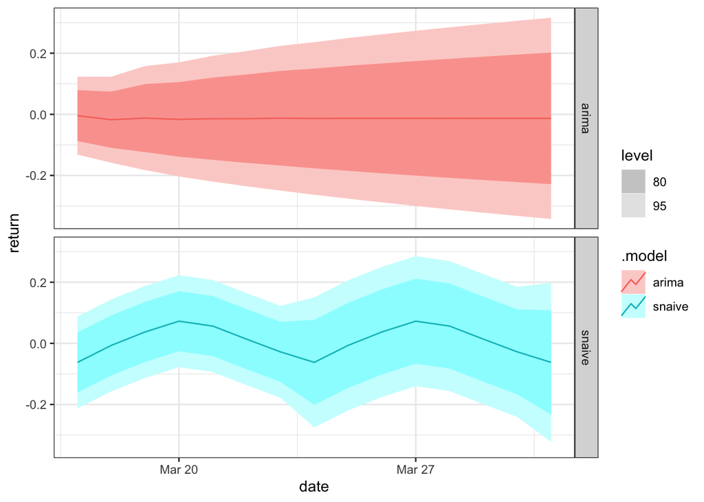

```r
library(fable)
library(tsibble)
library(feasts)
coin_hist |>
  na.omit() |>
  filter(symbol == "ETH") |>
  tsibble(index = date) |>
  model(
    arima = ARIMA(return ~ 1 + pdq()),
    snaive = SNAIVE(return)
  ) |>
  forecast(h = 15) |>
  autoplot() + theme_bw() + facet_grid(vars(.model))
```

Let’s have a look at the estimated coefficients from models.

```r
coin_hist |>
  na.omit() |>
  filter(symbol == "ETH") |>
  tsibble(index = date) |>
  model(
    arima = ARIMA(return ~ 1 + pdq()),
    snaive = SNAIVE(return)
  ) |>
  coef()
```

| .model | term | estimate | std.error | statistic | p.value |
| --- | --- | --- | --- | --- | --- |
| arima | ar1 | -0.5343421 | 0.0178175 | -29.9896975 | 0.0000000 |
| arima | sar1 | -0.0252163 | 0.0210651 | -1.1970613 | 0.2314085 |
| arima | constant | 0.0000123 | 0.0013710 | 0.0089548 | 0.9928560 |

Note: **sar** is an auto-regressive component with **seasonality**.  
We can specify a particular set of orders p, d and q.

```r
coin_hist |>
  na.omit() |>
  filter(symbol == "ETH") |>
  tsibble(index = date) |>
  model(
    arima = ARIMA(return ~ 1 + pdq(1,0,1)),
    snaive = SNAIVE(return)
  ) |>
  coef()
```

| .model | term | estimate | std.error | statistic | p.value |
| --- | --- | --- | --- | --- | --- |
| arima | ar1 | -0.7941743 | 0.1482942 | -5.355396 | 0.0000001 |
| arima | ma1 | 0.7680584 | 0.1548280 | 4.960718 | 0.0000008 |
| arima | constant | 0.0066511 | 0.0020068 | 3.314320 | 0.0009332 |